# 空間分析 Final Report

第八組

2025-06-07

#讀取資料

```r
health_sf = st_read("./data/臺北市健康餐飲.kml", options="ENCODING=BIG5")
```

```
options:        ENCODING=BIG5
```

```r
health_sf <- st_transform(health_sf, crs = 3826)
SCHOOL_sf = st_read("./data/SCHOOL.shp", options="ENCODING=BIG5")
```

```
options:        ENCODING=BIG5
```

```r
Taipei_Vill_sf = st_read("./data/Taipei_Vill.shp", options="ENCODING=BIG5")
```

```
options:        ENCODING=BIG5
```

```r
Tpe_Fastfood_sf = st_read("./data/Tpe_Fastfood.shp", options="ENCODING=BIG5")
```

```
options:        ENCODING=BIG5
```

# Part 1 - 實作題

## 第一題

假設速食店的服務範圍是 1 公里，比較 A 區(文山+大安+中正) 與 B 區(信義+南港+松山) 這兩個地區的每一家速食店在服務可及範圍內，所涵蓋學校數量的平均值，是否有統計顯著差異。(需列出虛無假設與對立假設，統計檢定量，以及檢定的顯著水準等)。

- $H_0$: A區平均值等於B區平均值
- $H_A$: A區平均值不等於B區平均值
- 顯著水準：$\alpha = 0.05$

```r
FAST_COUNTY_sf = st_join(Tpe_Fastfood_sf, Taipei_Vill_sf, join = st_within)
FAST_buffer_sf = st_buffer(FAST_COUNTY_sf, dist = 1000)
FAST_SCHOOL_sf = st_join(SCHOOL_sf, FAST_buffer_sf, join = st_within)

FAST_A_sf = filter(FAST_SCHOOL_sf, TOWN %in% c("文山區", "大安區", "中正區"))
FAST_B_sf = filter(FAST_SCHOOL_sf, TOWN %in% c("信義區", "南港區", "松山區"))

count_A_table = table(FAST_A_sf$ID)
count_B_table = table(FAST_B_sf$ID)

count_A_df = as.data.frame(count_A_table)
colnames(count_A_df) <- c("ALIAS","學校數")
count_B_df = as.data.frame(count_B_table)
colnames(count_B_df) <- c("ALIAS","學校數")

t.test(count_A_df$學校數, count_B_df$學校數, alternative = "two.sided")
```

```
    Welch Two Sample t-test

data:  count_A_df$學校數 and count_B_df$學校數
t = 1.5977, df = 51, p-value = 0.1163
alternative hypothesis: true difference in means is not equal to 0
95 percent confidence interval:
 -0.1418044  1.2473762
sample estimates:
mean of x mean of y
 3.870968  3.318182
```

- p-value=0.1163>$\alpha$，所以無法拒絕虛無假設，因此兩區的涵蓋學校數量的平均值，沒有統計顯著差異

## 第二題

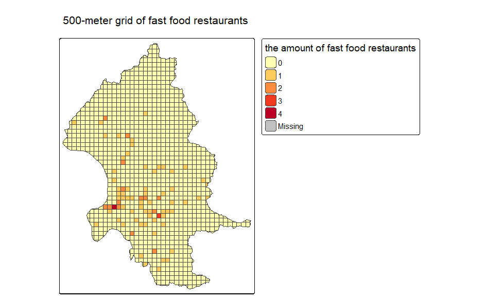

```r
# 建立 500 公尺網格
grid500 <- st_make_grid(Taipei_Vill_sf, cellsize = 500, square = TRUE) %>%
  st_sf() %>%
  st_intersection(st_union(Taipei_Vill_sf)) %>%
  st_sf()
st_crs(grid500) <- 3826

# 計算每格內速食店數量
grid500$Fastfood_N <- lengths(st_intersects(grid500, Tpe_Fastfood_sf))

# 建立 contiguity 鄰接關係 (queen)
nb_queen <- poly2nb(grid500, queen = TRUE)
lw_queen <- nb2listw(nb_queen, style = "W")

# 繪製網格 + 速食店數量
tmap_mode("plot")
tm_shape(grid500) +
  tm_polygons("Fastfood_N", palette = "YlOrRd", title = "the amount of fast food restaurants") +
  tm_layout(main.title = "500-meter grid of fast food restaurants")
```

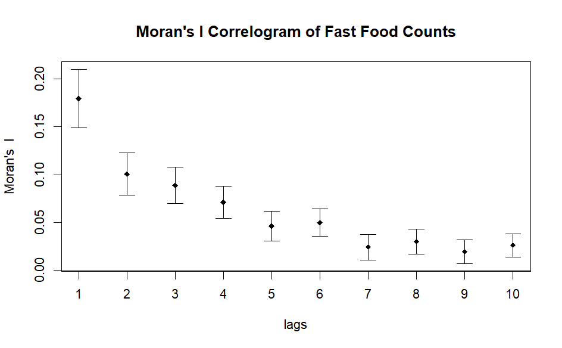

```r
# 計算 Moran’s I Correlogram（order = 10）
moran_corr <- sp.correlogram(nb_queen, grid500$Fastfood_N, order = 10, method = "I", style = "W")

# 繪圖
plot(moran_corr, main = "Moran's I Correlogram of Fast Food Counts")
```

[figure not shown]

```r
##### 額外：使用FDR校正 #####

# 計算前 10 階的 Moran's I
moran_corr <- sp.correlogram(nb_q, grid500$Fastfood_N, order = 10, method = "I", style = "W", zero.policy = TRUE)

# 轉成 dataframe 繪圖用
df_corr <- data.frame(
  Order = 1:10,
  I = moran_corr$res[, 1],  # 第一欄是 I
  p = moran_corr$res[, 2]   # 第二欄是 p 值
)

# 繪圖
ggplot(df_corr, aes(x = Order, y = I)) +
  geom_line() +
  geom_point(aes(color = p < 0.05), size = 3) +
  geom_hline(yintercept = 0, linetype = "dashed", color = "grey40") +
  scale_color_manual(values = c("FALSE" = "grey", "TRUE" = "red"), labels = c("Not Significant", "Significant")) +
  labs(title = "Moran's I Correlogram of Fast Food Counts",
       subtitle = "Spatial autocorrelation by contiguity order",
       x = "Contiguity Order", y = "Moran's I", color = "p < 0.05") +
  theme_minimal()
```

```r
##### 額外：使用FDR校正 #####

# 建立 500m 網格
grid500 <- st_make_grid(Taipei_Vill_sf, cellsize = 500, square = TRUE) %>%
  st_sf() %>%
  st_intersection(st_union(Taipei_Vill_sf)) %>%
  st_sf()
st_crs(grid500) <- 3826

# 加入每格速食店數量
grid500$Fastfood_N <- lengths(st_intersects(grid500, Tpe_Fastfood_sf))

# 建立鄰接關係（Queen）
nb_q <- poly2nb(grid500, queen = TRUE)
lw_q <- nb2listw(nb_q, style = "W", zero.policy = TRUE)

# 計算 Local Moran's I
lisa <- localmoran(grid500$Fastfood_N, lw_q, zero.policy = TRUE)

# 加入結果並 FDR 校正
grid500$Ii         <- lisa[,1]
grid500$EIi        <- lisa[,2]
grid500$VarIi      <- lisa[,3]
grid500$Z.Ii       <- lisa[,4]
grid500$p.Ii       <- lisa[,5]
grid500$p.Ii.fdr   <- p.adjust(lisa[,5], method = "fdr")

# LISA 分類（依照顯著性 + 正負相關）
lag_FF <- lag.listw(lw_q, grid500$Fastfood_N)
grid500$lag_FF <- lag_FF

grid500$LISA_type <- "Not significant"
grid500$LISA_type[grid500$Fastfood_N > mean(grid500$Fastfood_N) &
                  grid500$lag_FF > mean(grid500$lag_FF) &
                  grid500$p.Ii.fdr < 0.05] <- "High-High"
grid500$LISA_type[grid500$Fastfood_N < mean(grid500$Fastfood_N) &
                  grid500$lag_FF < mean(grid500$lag_FF) &
                  grid500$p.Ii.fdr < 0.05] <- "Low-Low"
grid500$LISA_type[grid500$Fastfood_N > mean(grid500$Fastfood_N) &
                  grid500$lag_FF < mean(grid500$lag_FF) &
                  grid500$p.Ii.fdr < 0.05] <- "High-Low"
grid500$LISA_type[grid500$Fastfood_N < mean(grid500$Fastfood_N) &
                  grid500$lag_FF > mean(grid500$lag_FF) &
                  grid500$p.Ii.fdr < 0.05] <- "Low-High"

grid500$LISA_type <- factor(grid500$LISA_type,
                            levels = c("High-High", "Low-Low", "High-Low", "Low-High", "Not significant"))

# 畫出 LISA 類型地圖
tmap_mode("plot")
```

```
ℹ tmap mode set to "plot".
```

[output not shown]

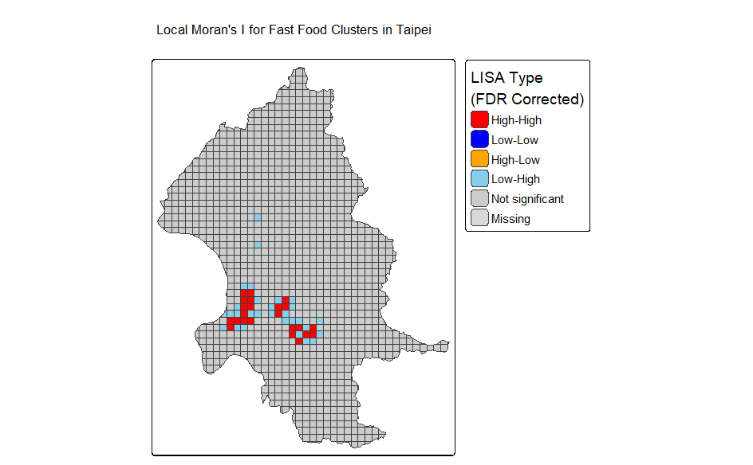

```r
tm_shape(grid500) +
  tm_polygons("LISA_type", palette = c("red", "blue", "orange", "skyblue", "grey80"),
              title = "LISA Type\n(FDR Corrected)") +
  tm_layout(main.title = "Local Moran's I for Fast Food Clusters in Taipei",
            legend.outside = TRUE)
```

速食店在空間上具有顯著的聚集現象，尤其在第 1 階（500 公尺鄰近）時 Moran’s I 約為 0.18，顯著高於 0，代表空間自相關強烈。

隨著鄰接階數增加，Moran’s I 值逐漸下降，但在前 6 階（即約 3 公里範圍內）仍維持正向且有顯著性，表示聚集效應具有一定的空間延伸範圍。

## 第三題

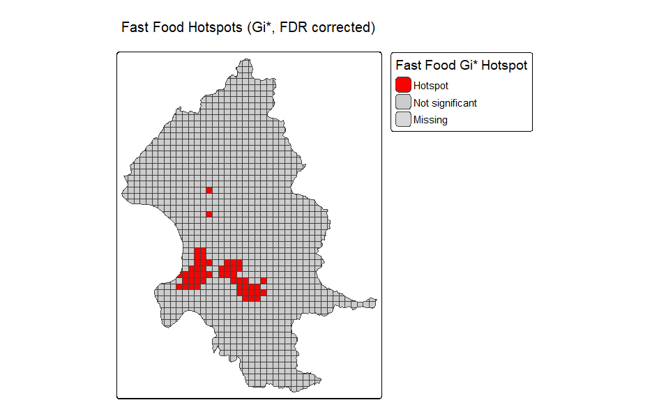

```r
# --- STEP 0: 建立學校數量欄位（與前面一樣） ---
grid500$School_N <- lengths(st_intersects(grid500, SCHOOL_sf))

# 建立 Queen 鄰接權重（如果還沒執行過）
nb_q <- poly2nb(grid500, queen = TRUE)
lw_q <- nb2listw(nb_q, style = "W", zero.policy = TRUE)

# 找出有鄰居的格子
valid_idx <- which(card(nb_q) > 0)

# 初始化並計算 Gi* 統計量
Gi_Z_FF <- rep(NA, nrow(grid500))
Gi_Z_FF[valid_idx] <- localG(grid500$Fastfood_N[valid_idx], lw_q, zero.policy = TRUE)

grid500$Gi_Z_FF <- Gi_Z_FF
grid500$p_FF <- 2 * pnorm(-abs(grid500$Gi_Z_FF))  # 雙尾 p 值
grid500$p_FF_fdr <- p.adjust(grid500$p_FF, method = "fdr")  # FDR 修正
grid500$Hotspot_FF <- ifelse(grid500$p_FF_fdr < 0.05 & grid500$Gi_Z_FF > 0, "Hotspot", "Not significant")

# 1. 計算 Gi* Z 值（學校）
Gi_Z_SC <- rep(NA, nrow(grid500))
Gi_Z_SC[valid_idx] <- localG(grid500$School_N[valid_idx], lw_q, zero.policy = TRUE)
grid500$Gi_Z_SC <- Gi_Z_SC

# 2. 計算 p 值與 FDR 校正
grid500$p_SC <- 2 * pnorm(-abs(grid500$Gi_Z_SC))
grid500$p_SC_fdr <- p.adjust(grid500$p_SC, method = "fdr")

# 3. 正確產出 Hotspot_SC
grid500$Hotspot_SC <- ifelse(
  is.na(grid500$p_SC_fdr), "Not significant",
  ifelse(grid500$p_SC_fdr < 0.05 & grid500$Gi_Z_SC > 0, "Hotspot", "Not significant")
)

# 4. 設定為 factor，避免 tmap 判定為 NA
grid500$Hotspot_SC <- factor(grid500$Hotspot_SC, levels = c("Hotspot", "Not significant"))
# --- STEP 2: 熱區圖繪製 ---

# 速食店熱區地圖
tm_shape(grid500) +
  tm_polygons("Hotspot_FF", palette = c("red", "grey80"),
              title = "Fast Food Gi* Hotspot") +
  tm_layout(main.title = "Fast Food Hotspots (Gi*, FDR corrected)",
            legend.outside = TRUE)
```

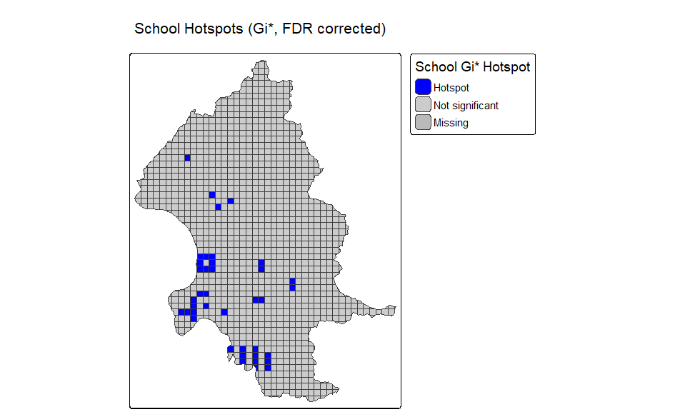

```r
# 學校熱區地圖
tm_shape(grid500) +
  tm_polygons("Hotspot_SC", palette = c("blue", "grey80"),
              title = "School Gi* Hotspot") +
  tm_layout(main.title = "School Hotspots (Gi*, FDR corrected)",
            legend.outside = TRUE)
```

結論（速食店與學校熱區）： 速食店熱區（紅色）主要集中於圖中南側偏中與東南區域，呈現連續聚集，顯示這些區域的速食店密度顯著高於其他地區。 學校熱區（藍色）則較為零星分布，雖也多集中於南側，但與速食店的熱區僅部分重疊，整體空間分布差異明顯。 兩者空間分布顯示：速食店熱區與學校熱區不完全一致，但有重疊。

# Part 2

## 第一題

```r
#讀取資料

fastfood <- st_read("./data/Tpe_Fastfood.shp", options="ENCODING=BIG5")
```

```
options:        ENCODING=BIG5
```

```r
villages <- st_read("./data/Taipei_Vill.shp", options="ENCODING=BIG5")
```

```
options:        ENCODING=BIG5
```

```r
schools <- st_read("./data/SCHOOL.shp", options="ENCODING=BIG5")
```

```
options:        ENCODING=BIG5
```

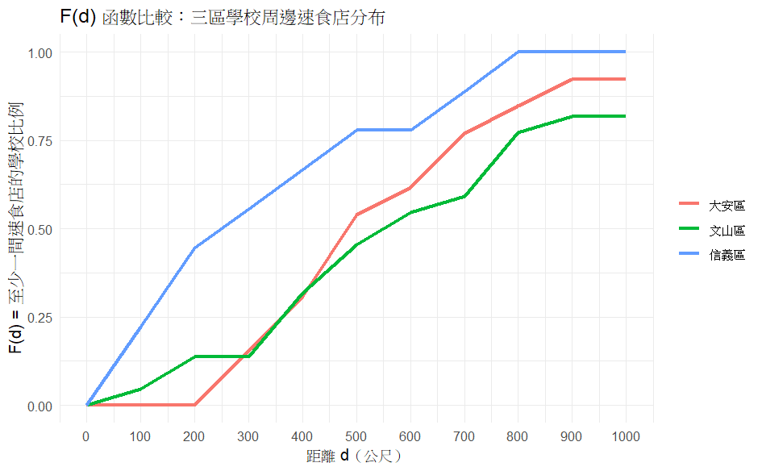

```r
#Step 2：選出三個行政區的學校（大安、文山、信義）
villages <- villages %>%
  filter(grepl("大安區|文山區|信義區", TOWN))  # 注意欄位名稱可能需對應你的資料，如 DISTRICT_NAME

#空間相交找出屬於三區的學校
schools_three <- st_join(schools, villages, join = st_within) %>%
  filter(!is.na(TOWN))  # 確保有交集成功

#計算每所學校到所有速食店的距離，並做 F(d) 函數

#定義距離門檻（以公尺為單位），這裡設定從 0 到 1000 公尺，每 100 公尺一個門檻
d_values <- seq(0, 1000, by = 100)

#建立一個函數計算 F(d) 值
calc_Fd <- function(schools_sf, fastfood_sf, d_seq) {
  result <- data.frame(distance = d_seq, Fd = NA)
  n_school <- nrow(schools_sf)

  for (i in seq_along(d_seq)) {
    d <- set_units(d_seq[i], "m") #單位為公尺

    #每間學校是否在 d 公尺內至少有一間速食店？
    count_within_d <- sum(sapply(1:n_school, function(j) {
      any(st_distance(schools_sf[j,], fastfood_sf) <= d)
    }))

    #F(d) = 滿足條件的學校數 / 總學校數
    result$Fd[i] <- count_within_d / n_school
  }
  return(result)
}

#分三區做 F(d)
fd_da_an <- calc_Fd(schools_three %>% filter(grepl("大安區", TOWN)), fastfood, d_values)
fd_wen_shan <- calc_Fd(schools_three %>% filter(grepl("文山區", TOWN)), fastfood, d_values)
fd_xin_yi <- calc_Fd(schools_three %>% filter(grepl("信義區", TOWN)), fastfood, d_values)

#加上區名
fd_da_an$District <- "大安區"
fd_wen_shan$District <- "文山區"
fd_xin_yi$District <- "信義區"

#合併資料
fd_all <- rbind(fd_da_an, fd_wen_shan, fd_xin_yi)

#繪圖比較 F(d)
ggplot(fd_all, aes(x = distance, y = Fd, color = District)) +
  geom_line(size = 1.2) +
  scale_x_continuous(breaks = d_values) +
  labs(
    title = "F(d) 函數比較：三區學校周邊速食店分布",
    x = "距離 d（公尺）",
    y = "F(d) = 至少一間速食店的學校比例"
  ) +
  theme_minimal() +
  theme(legend.title = element_blank())
```

```r
NA
NA
```

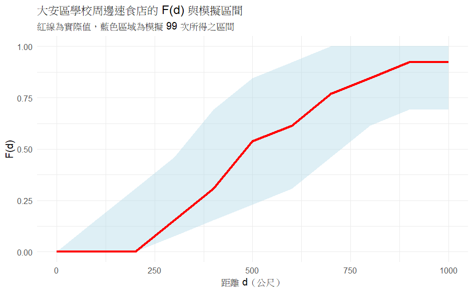

```r
set.seed(42)  #為了結果可重現

#只處理大安區
schools_da_an <- schools_three %>% filter(grepl("大安區", TOWN))
n_schools <- nrow(schools_da_an)
da_an_area <- villages %>% filter(TOWN == "大安區")

#模擬次數
n_sim <- 99

#建立一個空的 data frame 儲存模擬結果
sim_Fd_all <- matrix(NA, nrow = length(d_values), ncol = n_sim)

#進行模擬
for (i in 1:n_sim) {
  # 在大安區隨機產生 n_schools 個點
  random_pts <- st_sample(da_an_area, size = n_schools, type = "random") %>%
    st_as_sf()

  # 計算 F(d)
  sim_fd <- calc_Fd(random_pts, fastfood, d_values)

  # 存入模擬結果矩陣
  sim_Fd_all[, i] <- sim_fd$Fd
}

#產生模擬的 envelopes（最大值與最小值）
Fd_sim_min <- apply(sim_Fd_all, 1, min)
Fd_sim_max <- apply(sim_Fd_all, 1, max)

#合併為一個資料框
fd_envelope <- data.frame(
  distance = d_values,
  min = Fd_sim_min,
  max = Fd_sim_max
)

#加上實際的 F(d)
fd_actual <- fd_da_an  # 剛剛計算過的大安區實際 F(d)

#Step 6：繪圖（實際 vs. 模擬區間）
ggplot() +
  geom_ribbon(data = fd_envelope, aes(x = distance, ymin = min, ymax = max),
              fill = "lightblue", alpha = 0.4) +
  geom_line(data = fd_actual, aes(x = distance, y = Fd), color = "red", size = 1.2) +
  labs(
    title = "大安區學校周邊速食店的 F(d) 與模擬區間",
    subtitle = "紅線為實際值，藍色區域為模擬 99 次所得之區間",
    x = "距離 d（公尺）",
    y = "F(d)"
  ) +
  theme_minimal()
```

[figure not shown]

```r
set.seed(42)

#只處理信義區
schools_da_an <- schools_three %>% filter(grepl("信義區", TOWN))
n_schools <- nrow(schools_da_an)
da_an_area <- villages %>% filter(TOWN == "信義區")

#模擬次數
n_sim <- 99

#建立一個空的 data frame 儲存模擬結果
sim_Fd_all <- matrix(NA, nrow = length(d_values), ncol = n_sim)

#進行模擬
for (i in 1:n_sim) {
  #信義區隨機生成 n_schools 個點
  random_pts <- st_sample(da_an_area, size = n_schools, type = "random") %>%
    st_as_sf()

  # 計算 F(d)
  sim_fd <- calc_Fd(random_pts, fastfood, d_values)

  # 存入模擬結果矩陣
  sim_Fd_all[, i] <- sim_fd$Fd
}

#產生模擬的 envelopes（最大值與最小值）
Fd_sim_min <- apply(sim_Fd_all, 1, min)
Fd_sim_max <- apply(sim_Fd_all, 1, max)

#合併為一個資料框
fd_envelope <- data.frame(
  distance = d_values,
  min = Fd_sim_min,
  max = Fd_sim_max
)

#加上實際的 F(d)
fd_actual <- fd_da_an  # 剛剛計算過的信義區實際 F(d)

#Step 6：繪圖（實際 vs. 模擬區間）
ggplot() +
  geom_ribbon(data = fd_envelope, aes(x = distance, ymin = min, ymax = max),
              fill = "lightblue", alpha = 0.4) +
  geom_line(data = fd_actual, aes(x = distance, y = Fd), color = "red", size = 1.2) +
  labs(
    title = "信義區學校周邊速食店的 F(d) 與模擬區間",
    subtitle = "紅線為實際值，藍色區域為模擬 99 次所得之區間",
    x = "距離 d（公尺）",
    y = "F(d)"
  ) +
  theme_minimal()
```

[figure not shown]

```r
set.seed(42)

#只處理文山區
schools_da_an <- schools_three %>% filter(grepl("文山區", TOWN))
n_schools <- nrow(schools_da_an)
da_an_area <- villages %>% filter(TOWN == "文山區")

#模擬次數
n_sim <- 99

#建立一個空的 data frame 儲存模擬結果
sim_Fd_all <- matrix(NA, nrow = length(d_values), ncol = n_sim)

#進行模擬
for (i in 1:n_sim) {
  #文山區隨機生成 n_schools 個點
  random_pts <- st_sample(da_an_area, size = n_schools, type = "random") %>%
    st_as_sf()

  # 計算 F(d)
  sim_fd <- calc_Fd(random_pts, fastfood, d_values)

  # 存入模擬結果矩陣
  sim_Fd_all[, i] <- sim_fd$Fd
}

#產生模擬的 envelopes（最大值與最小值）
Fd_sim_min <- apply(sim_Fd_all, 1, min)
Fd_sim_max <- apply(sim_Fd_all, 1, max)

#合併為一個資料框
fd_envelope <- data.frame(
  distance = d_values,
  min = Fd_sim_min,
  max = Fd_sim_max
)

#加上實際的 F(d)
fd_actual <- fd_da_an  # 剛剛計算過的文山區實際 F(d)

#Step 6：繪圖（實際 vs. 模擬區間）
ggplot() +
  geom_ribbon(data = fd_envelope, aes(x = distance, ymin = min, ymax = max),
              fill = "lightblue", alpha = 0.4) +
  geom_line(data = fd_actual, aes(x = distance, y = Fd), color = "red", size = 1.2) +
  labs(
    title = "文山區學校周邊速食店的 F(d) 與模擬區間",
    subtitle = "紅線為實際值，藍色區域為模擬 99 次所得之區間",
    x = "距離 d（公尺）",
    y = "F(d)"
  ) +
  theme_minimal()
```

[output not shown]

## 第二題

```r
win_polygon <- st_as_sfc(st_bbox(Tpe_Fastfood_sf))
win <- as.owin(win_polygon)

coords <- st_coordinates(Tpe_Fastfood_sf)
fastfood_ppp <- ppp(x = coords[, 1], y = coords[, 2], window = win)

r_seq <- seq(0, 5000, by = 100)

k_result <- Kest(fastfood_ppp, r = r_seq)
k_3000 <- k_result$iso[which(k_result$r == 3000)]
l_3000 <- sqrt(k_3000 / pi) -3000

cat("K(3000) =", k_3000, "\n")
```

```
K(3000) = 60111493
```

```r
cat("L(3000) =", l_3000, "\n")
```

```
L(3000) = 1374.252
```

```r
env <- envelope(fastfood_ppp,
                fun = Kest,
                nsim = 99,
                r = r_seq,
                correction = "iso",
                savefuns = TRUE,
                savepatterns = TRUE,
                verbose = FALSE)

r_index <- which(env$r == 3000)
upper_L <- sqrt(env$hi[r_index] / pi) -3000
lower_L <- sqrt(env$lo[r_index] / pi) -3000

cat("95% CI for L(3000): [", lower_L, ",", upper_L, "]\n")
```

```
95% CI for L(3000): [ -159.3052 , 162.5662 ]
```

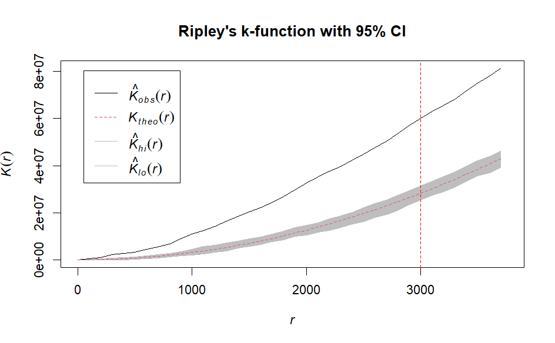

```r
plot(env, . ~ r, main = "Ripley's k-function with 95% CI")
abline(v = 3000, col = "red", lty = 2)
```

## 第三題

[figure not shown]

```r
public_sf <- subset(SCHOOL_sf, Type == "公立")
private_sf <- subset(SCHOOL_sf, Type == "私立")

coords_pub <- st_coordinates(public_sf)
coords_pri <- st_coordinates(private_sf)
coords_ff  <- st_coordinates(Tpe_Fastfood_sf)

win <- as.owin(st_as_sfc(st_bbox(SCHOOL_sf)))

pp_all_pub <- ppp(x = c(coords_pub[, 1], coords_ff[, 1]),
                  y = c(coords_pub[, 2], coords_ff[, 2]),
                  window = win,
                  marks = factor(c(rep("school", nrow(coords_pub)),
                                   rep("fastfood", nrow(coords_ff)))))

pp_all_pri <- ppp(x = c(coords_pri[, 1], coords_ff[, 1]),
                  y = c(coords_pri[, 2], coords_ff[, 2]),
                  window = win,
                  marks = factor(c(rep("school", nrow(coords_pri)),
                                   rep("fastfood", nrow(coords_ff)))))

# 使用更細的距離序列（每10公尺）
r_vals <- seq(0, 3000, by = 10)

# 公立學校 → 速食店
F_pub <- envelope(pp_all_pub,
                  fun = Fest,
                  i = "school",
                  j = "fastfood",
                  nsim = 99,
                  r = r_vals,
                  verbose = FALSE)

# 私立學校 → 速食店
F_pri <- envelope(pp_all_pri,
                  fun = Fest,
                  i = "school",
                  j = "fastfood",
                  nsim = 99,
                  r = r_vals,
                  verbose = FALSE)


# 公立學校
plot(F_pub, main = "公立學校 → 速食店 的 F-cross 函數", legendargs = list(cex = 0.8))
abline(h = F_pub$theo, col = "blue", lty = 2)
```

[figure not shown]

```r
# 私立學校
plot(F_pri, main = "私立學校 → 速食店 的 F-cross 函數", legendargs = list(cex = 0.8))
abline(h = F_pri$theo, col = "blue", lty = 2)
```

```r
r_target <- 1000  # 想比較的距離

idx_pub <- which.min(abs(F_pub$r - r_target))
idx_pri <- which.min(abs(F_pri$r - r_target))

# 取得各自的 F_cross(1000)
F_pub_obs <- F_pub$obs[idx_pub]
F_pri_obs <- F_pri$obs[idx_pri]

cat("F(1000) 公立學校 → 速食店 =", F_pub_obs, "\n")
```

```
F(1000) 公立學校 → 速食店 = 0.4083
```

```r
cat("F(1000) 私立學校 → 速食店 =", F_pri_obs, "\n")
```

```
F(1000) 私立學校 → 速食店 = 0.5777631
```

```r
plot(F_pub$r, F_pub$obs, type = "l", col = "blue", lwd = 2,
     ylim = c(0, max(F_pub$obs, F_pri$obs)),
     xlab = "距離 r", ylab = "F_cross(r)",
     main = "F-cross 比較：公立 vs 私立")
lines(F_pri$r, F_pri$obs, col = "red", lwd = 2)
```

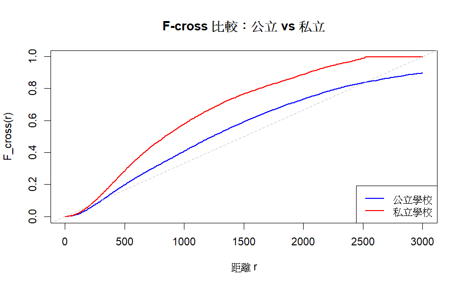

```r
legend("bottomright", legend = c("公立學校", "私立學校"), col = c("blue", "red"),
       lty = 1, lwd = 2)
abline(a = 0, b = 1 / max(F_pub$r), col = "gray", lty = 2)  # approx theo line
```

# Part 3

## 方法一：倡導學校引導學生選擇健康餐盒

```r
healthy_sf <- health_sf %>%
  mutate(行政區 = str_extract(Description, "行政區: [^<]+") %>%
                   str_remove("行政區: "))

health_sf <- healthy_sf %>%
  filter(行政區 == "信義區")

schools_sf = st_join(SCHOOL_sf, Taipei_Vill_sf, join = st_within)%>%
  filter(TOWN %in% c("信義區"))

win_polygon <- st_as_sfc(st_bbox(health_sf))
win <- as.owin(win_polygon)

coords <- st_coordinates(health_sf)
healthyfood_ppp <- ppp(x = coords[, 1], y = coords[, 2], window = win)

r_seq <- seq(0, 5000, by = 100)

k_result <- Kest(healthyfood_ppp, r = r_seq)
k_3000 <- k_result$iso[which(k_result$r == 3000)]
l_3000 <- sqrt(k_3000 / pi) -3000

cat("K(3000) =", k_3000, "\n")
```

```
K(3000) = NA
```

```r
cat("L(3000) =", l_3000, "\n")
```

```
L(3000) = NA
```

```r
env <- envelope(healthyfood_ppp,
                fun = Kest,
                nsim = 99,
                r = r_seq,
                correction = "iso",
                savefuns = TRUE,
                savepatterns = TRUE,
                verbose = FALSE)

r_index <- which(env$r == 3000)
upper_L <- sqrt(env$hi[r_index] / pi) -3000
lower_L <- sqrt(env$lo[r_index] / pi) -3000

cat("95% CI for L(3000): [", lower_L, ",", upper_L, "]\n")
```

```
95% CI for L(3000): [ NA , NA ]
```

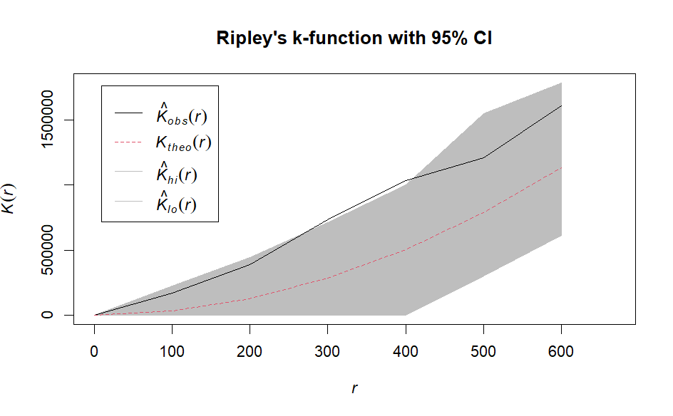

```r
plot(env, . ~ r, main = "Ripley's k-function with 95% CI")
abline(v = 3000, col = "red", lty = 2)
```

[figure not shown]

```r
coords_pub <- st_coordinates(schools_sf)
coords_ff  <- st_coordinates(health_sf)

win <- as.owin(st_as_sfc(st_bbox(schools_sf)))

pp_all_pub <- ppp(x = c(coords_pub[, 1], coords_ff[, 1]),
                  y = c(coords_pub[, 2], coords_ff[, 2]),
                  window = win,
                  marks = factor(c(rep("school", nrow(coords_pub)),
                                   rep("healthyfood", nrow(coords_ff)))))

r_vals <- seq(0, 3000, by = 2)

F_pub <- envelope(pp_all_pub,
                  fun = Fest,
                  i = "school",
                  j = "healthyfood",
                  nsim = 99,
                  r = r_vals,
                  verbose = FALSE)

plot(F_pub, main = "學校 → 健康餐盒店 的 F-cross 函數", legendargs = list(cex = 0.8))
abline(h = F_pub$theo, col = "blue", lty = 2)
```